# Week9_RMarkdown

Rachel Cohen

5/24/2018

Use a data set to show what we have learned in **R** and how to collaborate on **GitHub** and now create a **RMarkdownfile**.

The data that I chose was from FigShare and can be reached at [reef_fish](https://figshare.com/articles/RLS_reef_fish_dataset.csv/934320)

The data is on reef fish in Australia and New Zealand that was taken over a 3 year period. Each entry has a specific latitude and longitude that corresponds with the site and site code which I use to break up the data since it is so large (over 130,000 entries). Each entry is made by a diver who observed the fish families and counted the totals.

# Required Packages

```r
library(dplyr)
```

```r
library(ggplot2)
```

# Data [^1]

```r
reef_fish <- read.csv("data/RLSreeffishdataset.csv")
head(reef_fish)
```

```
##   SiteCode                Site   SiteLat SiteLong   Country
## 1     CG10 Steves Bommie (668) -31.68152  152.912 Australia
## 2     CG10 Steves Bommie (668) -31.68152  152.912 Australia
## 3     CG10 Steves Bommie (668) -31.68152  152.912 Australia
## 4     CG10 Steves Bommie (668) -31.68152  152.912 Australia
## 5     CG10 Steves Bommie (668) -31.68152  152.912 Australia
## 6     CG10 Steves Bommie (668) -31.68152  152.912 Australia
##            Ecoregion                 Realm SurveyID Depth SurveyDate Diver
## 1 Manning-Hawkesbury Temperate Australasia  2000859    30  17-May-09    MC
## 2 Manning-Hawkesbury Temperate Australasia  2000859    30  17-May-09    MC
## 3 Manning-Hawkesbury Temperate Australasia  2000859    30  17-May-09   DJA
## 4 Manning-Hawkesbury Temperate Australasia  2000859    30  17-May-09   DJA
## 5 Manning-Hawkesbury Temperate Australasia  2000859    30  17-May-09    MC
## 6 Manning-Hawkesbury Temperate Australasia  2000859    30  17-May-09   DJA
##                     Taxon           Family Block Total
## 1  Acanthistius ocellatus       Serranidae     2     1
## 2 Acanthopagrus australis         Sparidae     2     5
## 3      Achoerodus viridis         Labridae     1     2
## 4   Atypichthys strigatus      Scorpididae     1   100
## 5   Atypichthys strigatus      Scorpididae     2     5
## 6   Cheilodactylus fuscus Cheilodactylidae     1   200
```

Because the data is so large when I first made graphs they did not show any real information. So I then only focused on the first 2 sites Steves Bommie (668) *CG10* and SE lumps (66A) *CG11*. I only wanted the columns SiteCode for identification, Diver, Family and Total count of fish of that family.

```r
CG10_site <- select(reef_fish, SiteCode, Diver, Family, Total) %>%
  filter(SiteCode == "CG10")
head(CG10_site)
```

```
##   SiteCode Diver           Family Total
## 1     CG10    MC       Serranidae     1
## 2     CG10    MC         Sparidae     5
## 3     CG10   DJA         Labridae     2
## 4     CG10   DJA      Scorpididae   100
## 5     CG10    MC      Scorpididae     5
## 6     CG10   DJA Cheilodactylidae   200
```

```r
CG11_site <- select(reef_fish, SiteCode, Diver, Family, Total) %>%
  filter(SiteCode == "CG11")
head(CG11_site)
```

```
##   SiteCode Diver           Family Total
## 1     CG11   DJA        Aulopidae     1
## 2     CG11   DJA Cheilodactylidae     3
## 3     CG11   DJA    Pomacentridae     3
## 4     CG11    MC    Pomacentridae    30
## 5     CG11   DJA         Labridae    11
## 6     CG11    MC         Labridae     1
```

Graphing these new data sets. I want to see if there is an obvious bias in the divers if one counts more of one family than the others. I use a scatter plot to show the count of each entry that the Diver made and a bar graph to show the entries that the diver made.

### Scatter plot

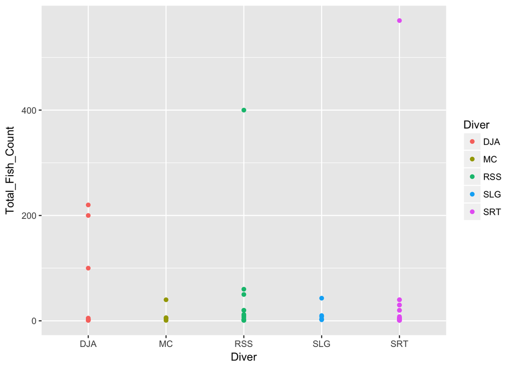

```r
ggplot(CG10_site, aes(Diver, Total, color = Diver)) +
  geom_point() +
  labs(x = "Diver", y = "Total_Fish_Count")
```

### Bar Graph

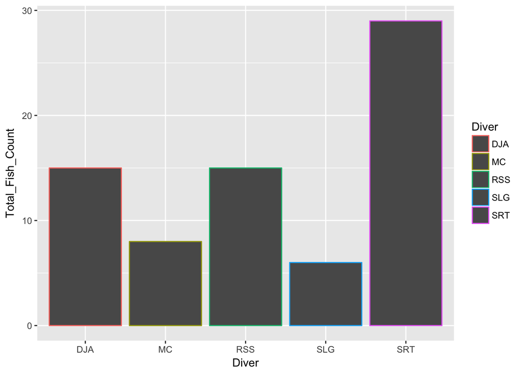

```r
ggplot(CG10_site, aes(Diver, color = Diver)) +
  geom_bar() +
  labs(x = "Diver", y = "Total_Fish_Count")
```

### Facet wrap by Family

Want to see if there is a difference between what divers see at the sight, see if the counts are high for a single Family or if one diver counts more than all the others.

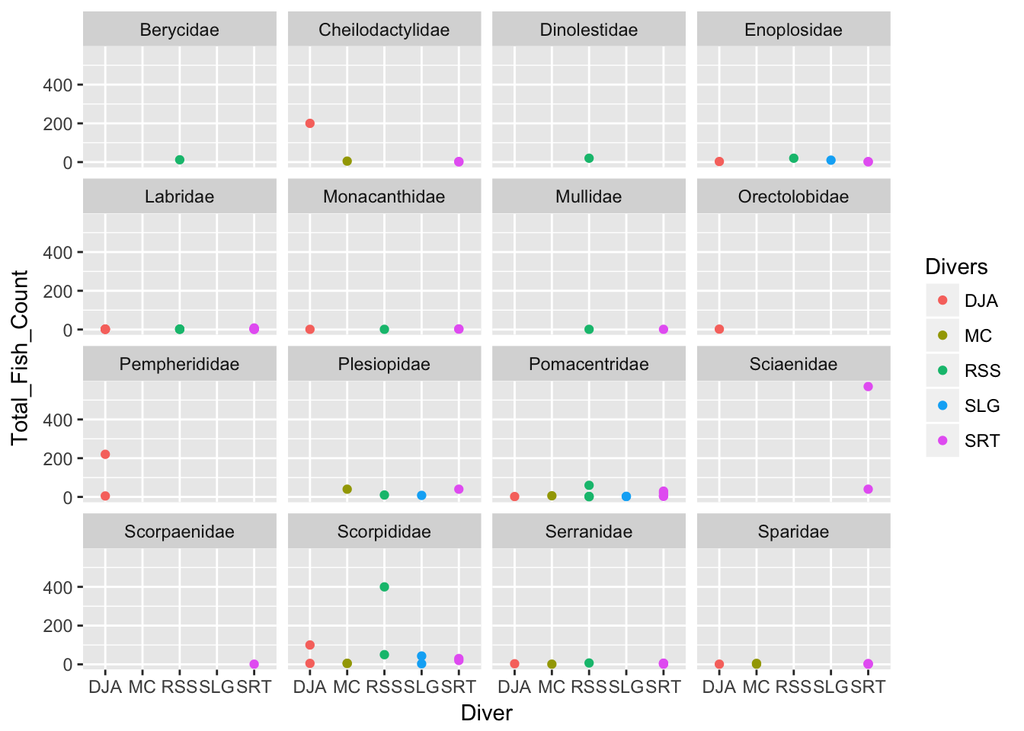

```r
ggplot(CG10_site, aes(Diver, Total, color = Diver)) +
  geom_point() +
  facet_wrap("Family") +
  labs(x = "Diver", y = "Total_Fish_Count", color = "Divers")
```

**DJA** is the only diver to see *Pempherididae* and sees 220 during a dive and 5 during another. Is the only one to see *Orectolobidae*. Also sees a high count of *Cheilodactylidae*. **RSS** is the only diver to see both *Bercidae* and *Dinolestidae*. **SRT** is the only diver to see *Scianidae* and *Scorpaenidae*.

Now do the same graphs for the second site **CG11**

### Scatter Plot of diver entries and their totals

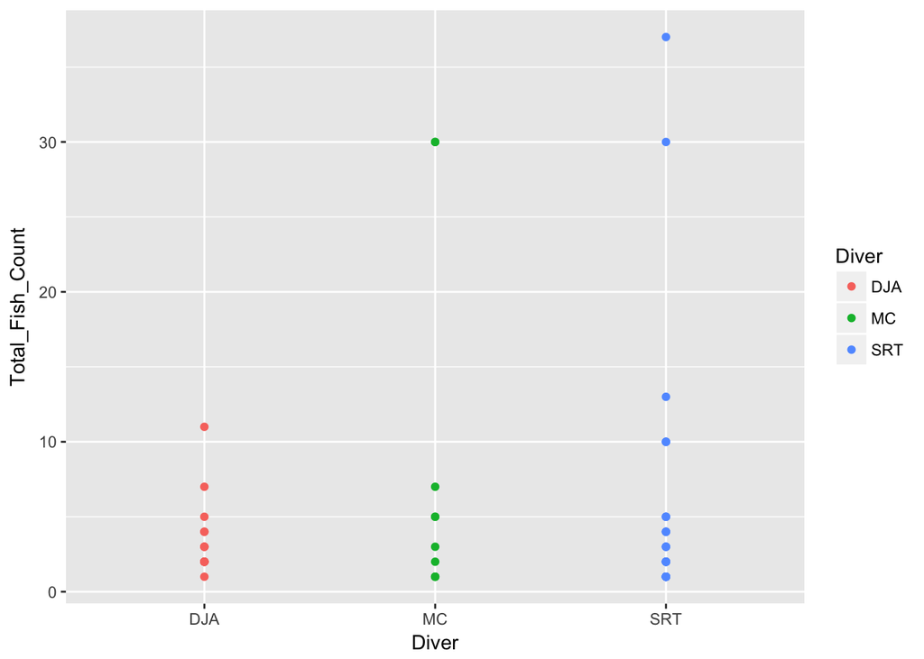

```r
ggplot(CG11_site, aes(Diver, Total, color = Diver)) +
  geom_point() +
  labs(x = "Diver", y = "Total_Fish_Count")
```

### Bar Graph of Diver entries

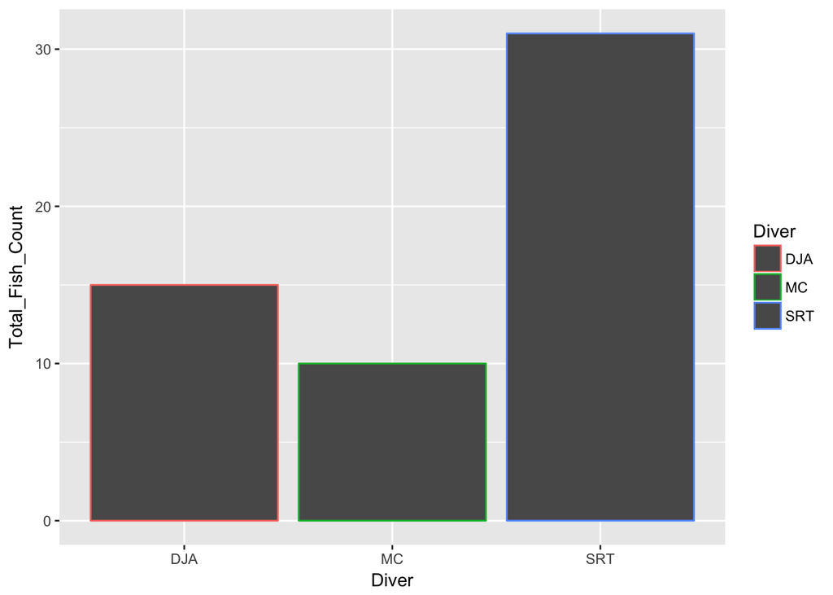

```r
ggplot(CG11_site, aes(Diver, color = Diver)) +
  geom_bar() +
  labs(x = "Diver", y = "Total_Fish_Count")
```

### Facet Plots by family

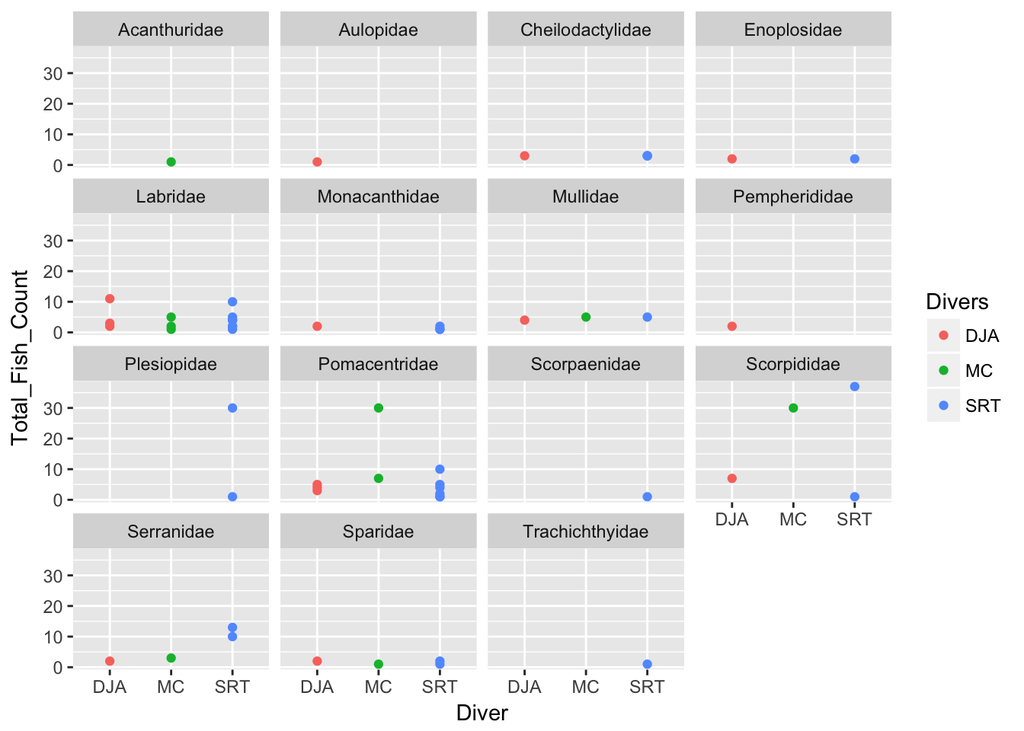

```r
ggplot(CG11_site, aes(Diver, Total, color = Diver)) +
  geom_point() +
  facet_wrap("Family") +
  labs(x = "Diver", y = "Total_Fish_Count", color = "Divers")
```

Diver **SRT** has an entry for 12/15 species, **DJA** has 11/15, and **MC** has 7/15.

I want to see the Families and counts that each Diver individually sees. Let us make a facet wrap by diver

## Site CG10

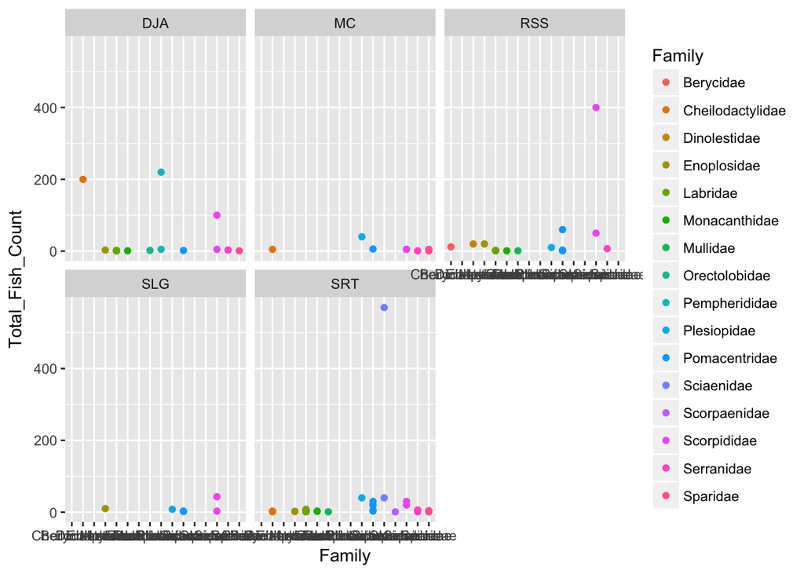

```r
ggplot(CG10_site, aes(Family, Total, color = Family)) +
  geom_point() +
  facet_wrap("Diver") +
  labs(x = "Family", y = "Total_Fish_Count", color = "Family")
```

## CG11

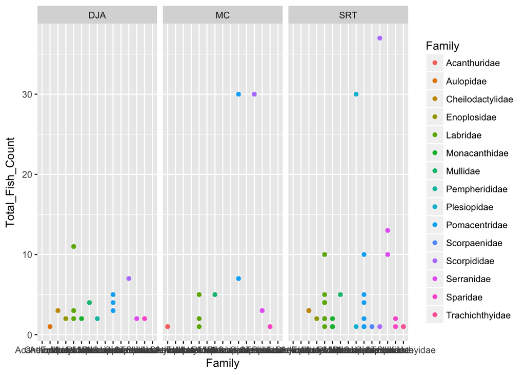

```r
ggplot(CG11_site, aes(Family, Total, color = Family)) +
  geom_point() +
  facet_wrap("Diver") +
  labs(x = "Family", y = "Total_Fish_Count", color = "Family")
```

[^1]: This data is really large so do not run code in the script that uses the whole data set. It will take a long time